# Assignment_3_Part_3

## Exercise

For this exercise, you will be working with the [House Price Dataset](https://www.kaggle.com/competitions/house-prices-advanced-regression-techniques/code).

Please grab the train.csv file from Kaggle and explore this dataset. You need to perform explroatory data analysis and see if there is any correlation between the variables and analyze the distribution of the dataset. The question is open-ended and basically you're asked to perform EDA.

1- Write a summary of your findings in one page (e.g., summary statistics, plots) and submit the pdf file. Therefore, for part 3 of your assignment, you need to submit at least one jupyter notebook file and one pdf file.

2- Push your code and project to github and provide the link to your code here. Ensure that your github project is organized to at least couple of main folders, ensure that you have the README file as well:

- Src
- Data
- Docs
- Results

Read this link for further info: https://gist.github.com/ericmjl/27e50331f24db3e8f957d1fe7bbbe510

### Overview

There are **1460** instances of training data

## Read Data

```python
import pandas as pd
df_ss=pd.read_csv('..\\Data\\sample_submission.csv')
df_test=pd.read_csv('..\\Data\\test.csv')
df_train=pd.read_csv('..\\Data\\train.csv')
```

```python
df_ss.head()
```

|  | Id | SalePrice |
| --- | --- | --- |
| 0 | 1461 | 169277.052498 |
| 1 | 1462 | 187758.393989 |
| 2 | 1463 | 183583.683570 |
| 3 | 1464 | 179317.477511 |
| 4 | 1465 | 150730.079977 |

```python
df_test.head()
```

|  | Id | MSSubClass | MSZoning | LotFrontage | LotArea | Street | Alley | LotShape | LandContour | Utilities | ... | ScreenPorch | PoolArea | PoolQC | Fence | MiscFeature | MiscVal | MoSold | YrSold | SaleType | SaleCondition |
| --- | --- | --- | --- | --- | --- | --- | --- | --- | --- | --- | --- | --- | --- | --- | --- | --- | --- | --- | --- | --- | --- |
| 0 | 1461 | 20 | RH | 80.0 | 11622 | Pave | NaN | Reg | Lvl | AllPub | ... | 120 | 0 | NaN | MnPrv | NaN | 0 | 6 | 2010 | WD | Normal |
| 1 | 1462 | 20 | RL | 81.0 | 14267 | Pave | NaN | IR1 | Lvl | AllPub | ... | 0 | 0 | NaN | NaN | Gar2 | 12500 | 6 | 2010 | WD | Normal |
| 2 | 1463 | 60 | RL | 74.0 | 13830 | Pave | NaN | IR1 | Lvl | AllPub | ... | 0 | 0 | NaN | MnPrv | NaN | 0 | 3 | 2010 | WD | Normal |
| 3 | 1464 | 60 | RL | 78.0 | 9978 | Pave | NaN | IR1 | Lvl | AllPub | ... | 0 | 0 | NaN | NaN | NaN | 0 | 6 | 2010 | WD | Normal |
| 4 | 1465 | 120 | RL | 43.0 | 5005 | Pave | NaN | IR1 | HLS | AllPub | ... | 144 | 0 | NaN | NaN | NaN | 0 | 1 | 2010 | WD | Normal |

5 rows × 80 columns

```python
df_train.head()
```

|  | Id | MSSubClass | MSZoning | LotFrontage | LotArea | Street | Alley | LotShape | LandContour | Utilities | ... | PoolArea | PoolQC | Fence | MiscFeature | MiscVal | MoSold | YrSold | SaleType | SaleCondition | SalePrice |
| --- | --- | --- | --- | --- | --- | --- | --- | --- | --- | --- | --- | --- | --- | --- | --- | --- | --- | --- | --- | --- | --- |
| 0 | 1 | 60 | RL | 65.0 | 8450 | Pave | NaN | Reg | Lvl | AllPub | ... | 0 | NaN | NaN | NaN | 0 | 2 | 2008 | WD | Normal | 208500 |
| 1 | 2 | 20 | RL | 80.0 | 9600 | Pave | NaN | Reg | Lvl | AllPub | ... | 0 | NaN | NaN | NaN | 0 | 5 | 2007 | WD | Normal | 181500 |
| 2 | 3 | 60 | RL | 68.0 | 11250 | Pave | NaN | IR1 | Lvl | AllPub | ... | 0 | NaN | NaN | NaN | 0 | 9 | 2008 | WD | Normal | 223500 |
| 3 | 4 | 70 | RL | 60.0 | 9550 | Pave | NaN | IR1 | Lvl | AllPub | ... | 0 | NaN | NaN | NaN | 0 | 2 | 2006 | WD | Abnorml | 140000 |
| 4 | 5 | 60 | RL | 84.0 | 14260 | Pave | NaN | IR1 | Lvl | AllPub | ... | 0 | NaN | NaN | NaN | 0 | 12 | 2008 | WD | Normal | 250000 |

5 rows × 81 columns

To get access to all columns including the dependent variable for prediction **SalePrice**, the dataframe chose to this EDA is *df_train*

## General review

First, it is important to know the data, including its *data type* of all dataframe attributes and the number of *missing values*</i> present

### Data Type

Before checking the missing values, it is important identify if the data type are well defined regarding its content

```python
df_train.info()
```

```
<class 'pandas.core.frame.DataFrame'>
RangeIndex: 1460 entries, 0 to 1459
Data columns (total 81 columns):
 #   Column         Non-Null Count  Dtype
---  ------         --------------  -----
 0   Id             1460 non-null   int64
 1   MSSubClass     1460 non-null   int64
 2   MSZoning       1460 non-null   object
 3   LotFrontage    1201 non-null   float64
 4   LotArea        1460 non-null   int64
 5   Street         1460 non-null   object
 6   Alley          91 non-null     object
 7   LotShape       1460 non-null   object
 8   LandContour    1460 non-null   object
 9   Utilities      1460 non-null   object
```

[output cut: 73 more lines]

There are inconsistence in the columns types for example:

- All columns that refers to Year are int type. Even though they are numbers, it does not make sence if sum 2013+2016 or 2013*2016, we won´t do calculation with this numbers. In order how to identify all over the columns if they are set in a aproppiated data type is check one by one.

There are inconsistences in the data type of the dataframe columns:

**There are inconsistences in the data type of the dataframe columns:**

For example:

- All **"Year"** columns are *Integer* type.
- **OverallCond** is *integer type* in the dataset since its content are numbers, but it is actually categories.

Even though the column content are numbers, it does not mean they are.

**For example:**There is no sense if we do these calculations:

$2013+2016$ or $2013*2016$

We do not do these calculation with Years. So,in order to identify all over the columns with its aproppiated data type, the unique values needs to be identify, as it's shown in the following code:

```python
d={}
for i in df_train.columns:
    d.update({i:(len(df_train[i].unique()), list(df_train[i].unique()) )})
```

```python
pd.set_option('display.max_rows', None, 'display.max_columns', None)
df_unique=pd.DataFrame(d).transpose().sort_values(by=0,ascending=False)
#df_unique[df_unique.Len<5]
df_unique.columns=['Len','Categories']
df_unique
```

|  | Len | Categories |
| --- | --- | --- |
| Id | 1460 | [1, 2, 3, 4, 5, 6, 7, 8, 9, 10, 11, 12, 13, 14... |
| LotArea | 1073 | [8450, 9600, 11250, 9550, 14260, 14115, 10084,... |
| GrLivArea | 861 | [1710, 1262, 1786, 1717, 2198, 1362, 1694, 209... |
| BsmtUnfSF | 780 | [150, 284, 434, 540, 490, 64, 317, 216, 952, 1... |
| 1stFlrSF | 753 | [856, 1262, 920, 961, 1145, 796, 1694, 1107, 1... |
| TotalBsmtSF | 721 | [856, 1262, 920, 756, 1145, 796, 1686, 1107, 9... |
| SalePrice | 663 | [208500, 181500, 223500, 140000, 250000, 14300... |
| BsmtFinSF1 | 637 | [706, 978, 486, 216, 655, 732, 1369, 859, 0, 8... |
| GarageArea | 441 | [548, 460, 608, 642, 836, 480, 636, 484, 468, ... |
| 2ndFlrSF | 417 | [854, 0, 866, 756, 1053, 566, 983, 752, 1142, ... |
| MasVnrArea | 328 | [196.0, 0.0, 162.0, 350.0, 186.0, 240.0, 286.0... |
| WoodDeckSF | 274 | [0, 298, 192, 40, 255, 235, 90, 147, 140, 160,... |
| OpenPorchSF | 202 | [61, 0, 42, 35, 84, 30, 57, 204, 4, 21, 33, 21... |
| BsmtFinSF2 | 144 | [0, 32, 668, 486, 93, 491, 506, 712, 362, 41, ... |
| EnclosedPorch | 120 | [0, 272, 228, 205, 176, 87, 172, 102, 37, 144,... |
| YearBuilt | 112 | [2003, 1976, 2001, 1915, 2000, 1993, 2004, 197... |
| LotFrontage | 111 | [65.0, 80.0, 68.0, 60.0, 84.0, 85.0, 75.0, nan... |
| GarageYrBlt | 98 | [2003.0, 1976.0, 2001.0, 1998.0, 2000.0, 1993.... |
| ScreenPorch | 76 | [0, 176, 198, 291, 252, 99, 184, 168, 130, 142... |
| YearRemodAdd | 61 | [2003, 1976, 2002, 1970, 2000, 1995, 2005, 197... |
| Neighborhood | 25 | [CollgCr, Veenker, Crawfor, NoRidge, Mitchel, ... |
| LowQualFinSF | 24 | [0, 360, 513, 234, 528, 572, 144, 392, 371, 39... |
| MiscVal | 21 | [0, 700, 350, 500, 400, 480, 450, 15500, 1200,... |
| 3SsnPorch | 20 | [0, 320, 407, 130, 180, 168, 140, 508, 238, 24... |
| Exterior2nd | 16 | [VinylSd, MetalSd, Wd Shng, HdBoard, Plywood, ... |
| MSSubClass | 15 | [60, 20, 70, 50, 190, 45, 90, 120, 30, 85, 80,... |
| Exterior1st | 15 | [VinylSd, MetalSd, Wd Sdng, HdBoard, BrkFace, ... |
| MoSold | 12 | [2, 5, 9, 12, 10, 8, 11, 4, 1, 7, 3, 6] |
| TotRmsAbvGrd | 12 | [8, 6, 7, 9, 5, 11, 4, 10, 12, 3, 2, 14] |
| OverallQual | 10 | [7, 6, 8, 5, 9, 4, 10, 3, 1, 2] |

[output cut: 51 more lines]

Prior, I have checked the output of the previous table to identify the correct data type. The list that contains this results is saved into datatype variable:

```python
datatype=['int', 'int', 'int', 'int', 'int', 'int', 'int', 'int', 'int', 'int', 'float', 'int', 'int', 'int', 'int', 'cat', 'float', 'cat', 'int', 'cat', 'cat', 'int', 'int', 'int', 'cat', 'cat', 'cat', 'cat', 'cat', 'cat', 'cat', 'cat', 'cat', 'cat', 'int', 'cat', 'cat', 'cat', 'cat', 'cat', 'cat', 'cat', 'cat', 'cat', 'cat', 'cat', 'cat', 'cat', 'cat', 'cat', 'cat', 'cat', 'cat', 'cat', 'cat', 'cat', 'cat', 'cat', 'cat', 'cat', 'cat', 'cat', 'cat', 'cat', 'cat', 'cat', 'cat', 'cat', 'cat', 'cat', 'cat', 'cat', 'cat', 'cat', 'cat', 'cat', 'cat', 'cat', 'cat', 'cat', 'cat']
```

Let´s merge this list into the dataframe df_unique

```python
df_unique['Correct_datatype']=datatype
```

```python
df_unique
```

|  | Len | Categories | Correct_datatype |
| --- | --- | --- | --- |
| Id | 1460 | [1, 2, 3, 4, 5, 6, 7, 8, 9, 10, 11, 12, 13, 14... | int |
| LotArea | 1073 | [8450, 9600, 11250, 9550, 14260, 14115, 10084,... | int |
| GrLivArea | 861 | [1710, 1262, 1786, 1717, 2198, 1362, 1694, 209... | int |
| BsmtUnfSF | 780 | [150, 284, 434, 540, 490, 64, 317, 216, 952, 1... | int |
| 1stFlrSF | 753 | [856, 1262, 920, 961, 1145, 796, 1694, 1107, 1... | int |
| TotalBsmtSF | 721 | [856, 1262, 920, 756, 1145, 796, 1686, 1107, 9... | int |
| SalePrice | 663 | [208500, 181500, 223500, 140000, 250000, 14300... | int |
| BsmtFinSF1 | 637 | [706, 978, 486, 216, 655, 732, 1369, 859, 0, 8... | int |
| GarageArea | 441 | [548, 460, 608, 642, 836, 480, 636, 484, 468, ... | int |
| 2ndFlrSF | 417 | [854, 0, 866, 756, 1053, 566, 983, 752, 1142, ... | int |
| MasVnrArea | 328 | [196.0, 0.0, 162.0, 350.0, 186.0, 240.0, 286.0... | float |
| WoodDeckSF | 274 | [0, 298, 192, 40, 255, 235, 90, 147, 140, 160,... | int |
| OpenPorchSF | 202 | [61, 0, 42, 35, 84, 30, 57, 204, 4, 21, 33, 21... | int |
| BsmtFinSF2 | 144 | [0, 32, 668, 486, 93, 491, 506, 712, 362, 41, ... | int |
| EnclosedPorch | 120 | [0, 272, 228, 205, 176, 87, 172, 102, 37, 144,... | int |
| YearBuilt | 112 | [2003, 1976, 2001, 1915, 2000, 1993, 2004, 197... | cat |
| LotFrontage | 111 | [65.0, 80.0, 68.0, 60.0, 84.0, 85.0, 75.0, nan... | float |
| GarageYrBlt | 98 | [2003.0, 1976.0, 2001.0, 1998.0, 2000.0, 1993.... | cat |
| ScreenPorch | 76 | [0, 176, 198, 291, 252, 99, 184, 168, 130, 142... | int |
| YearRemodAdd | 61 | [2003, 1976, 2002, 1970, 2000, 1995, 2005, 197... | cat |
| Neighborhood | 25 | [CollgCr, Veenker, Crawfor, NoRidge, Mitchel, ... | cat |
| LowQualFinSF | 24 | [0, 360, 513, 234, 528, 572, 144, 392, 371, 39... | int |
| MiscVal | 21 | [0, 700, 350, 500, 400, 480, 450, 15500, 1200,... | int |
| 3SsnPorch | 20 | [0, 320, 407, 130, 180, 168, 140, 508, 238, 24... | int |
| Exterior2nd | 16 | [VinylSd, MetalSd, Wd Shng, HdBoard, Plywood, ... | cat |
| MSSubClass | 15 | [60, 20, 70, 50, 190, 45, 90, 120, 30, 85, 80,... | cat |
| Exterior1st | 15 | [VinylSd, MetalSd, Wd Sdng, HdBoard, BrkFace, ... | cat |
| MoSold | 12 | [2, 5, 9, 12, 10, 8, 11, 4, 1, 7, 3, 6] | cat |
| TotRmsAbvGrd | 12 | [8, 6, 7, 9, 5, 11, 4, 10, 12, 3, 2, 14] | cat |
| OverallQual | 10 | [7, 6, 8, 5, 9, 4, 10, 3, 1, 2] | cat |

[output cut: 51 more lines]

#### Each value in the column Categories from dataframe df_unique corresponds to:

| **int** |  | **float** |  | **cat** |  |
| --- | --- | --- | --- | --- | --- |
| Integer |  | Float |  | Category |  |

Proceed to converted the columns into its correspond type showed in the datafarame df_unique.

```python
for x in df_unique.reset_index().values:
    if x[3]=='int':
        df_train[x[0]]=df_train[x[0]].astype('int64')
    elif x[3]=='float':
        df_train[x[0]]=df_train[x[0]].astype('float64')
    elif x[3]=='cat':
        df_train[x[0]]=df_train[x[0]].astype('category')
```

```python
df_train.info()
```

```
<class 'pandas.core.frame.DataFrame'>
RangeIndex: 1460 entries, 0 to 1459
Data columns (total 81 columns):
 #   Column         Non-Null Count  Dtype
---  ------         --------------  -----
 0   Id             1460 non-null   int64
 1   MSSubClass     1460 non-null   category
 2   MSZoning       1460 non-null   category
 3   LotFrontage    1201 non-null   float64
 4   LotArea        1460 non-null   int64
 5   Street         1460 non-null   category
 6   Alley          91 non-null     category
 7   LotShape       1460 non-null   category
 8   LandContour    1460 non-null   category
 9   Utilities      1460 non-null   category
```

[output cut: 73 more lines]

We got **60 Categorical** variables , **18 Numerical** Variables (excluding Id) and **2 float** Variables.

```python
categories=list(filter(lambda x: x if df_train[x].dtypes=='category' else False,df_train.columns))
floats=list(filter(lambda x: x if df_train[x].dtypes=='float64' else False,df_train.columns))
integers=list(filter(lambda x: x if df_train[x].dtypes=='int64' else False,df_train.columns))
integers.remove('Id')
```

Once the convertion is succeded, let´s use df.describe()

```python
df_train.describe()
```

|  | Id | LotFrontage | LotArea | MasVnrArea | BsmtFinSF1 | BsmtFinSF2 | BsmtUnfSF | TotalBsmtSF | 1stFlrSF | 2ndFlrSF | LowQualFinSF | GrLivArea | GarageArea | WoodDeckSF | OpenPorchSF | EnclosedPorch | 3SsnPorch | ScreenPorch | PoolArea | MiscVal | SalePrice |
| --- | --- | --- | --- | --- | --- | --- | --- | --- | --- | --- | --- | --- | --- | --- | --- | --- | --- | --- | --- | --- | --- |
| count | 1460.000000 | 1201.000000 | 1460.000000 | 1452.000000 | 1460.000000 | 1460.000000 | 1460.000000 | 1460.000000 | 1460.000000 | 1460.000000 | 1460.000000 | 1460.000000 | 1460.000000 | 1460.000000 | 1460.000000 | 1460.000000 | 1460.000000 | 1460.000000 | 1460.000000 | 1460.000000 | 1460.000000 |
| mean | 730.500000 | 70.049958 | 10516.828082 | 103.685262 | 443.639726 | 46.549315 | 567.240411 | 1057.429452 | 1162.626712 | 346.992466 | 5.844521 | 1515.463699 | 472.980137 | 94.244521 | 46.660274 | 21.954110 | 3.409589 | 15.060959 | 2.758904 | 43.489041 | 180921.195890 |
| std | 421.610009 | 24.284752 | 9981.264932 | 181.066207 | 456.098091 | 161.319273 | 441.866955 | 438.705324 | 386.587738 | 436.528436 | 48.623081 | 525.480383 | 213.804841 | 125.338794 | 66.256028 | 61.119149 | 29.317331 | 55.757415 | 40.177307 | 496.123024 | 79442.502883 |
| min | 1.000000 | 21.000000 | 1300.000000 | 0.000000 | 0.000000 | 0.000000 | 0.000000 | 0.000000 | 334.000000 | 0.000000 | 0.000000 | 334.000000 | 0.000000 | 0.000000 | 0.000000 | 0.000000 | 0.000000 | 0.000000 | 0.000000 | 0.000000 | 34900.000000 |
| 25% | 365.750000 | 59.000000 | 7553.500000 | 0.000000 | 0.000000 | 0.000000 | 223.000000 | 795.750000 | 882.000000 | 0.000000 | 0.000000 | 1129.500000 | 334.500000 | 0.000000 | 0.000000 | 0.000000 | 0.000000 | 0.000000 | 0.000000 | 0.000000 | 129975.000000 |
| 50% | 730.500000 | 69.000000 | 9478.500000 | 0.000000 | 383.500000 | 0.000000 | 477.500000 | 991.500000 | 1087.000000 | 0.000000 | 0.000000 | 1464.000000 | 480.000000 | 0.000000 | 25.000000 | 0.000000 | 0.000000 | 0.000000 | 0.000000 | 0.000000 | 163000.000000 |
| 75% | 1095.250000 | 80.000000 | 11601.500000 | 166.000000 | 712.250000 | 0.000000 | 808.000000 | 1298.250000 | 1391.250000 | 728.000000 | 0.000000 | 1776.750000 | 576.000000 | 168.000000 | 68.000000 | 0.000000 | 0.000000 | 0.000000 | 0.000000 | 0.000000 | 214000.000000 |
| max | 1460.000000 | 313.000000 | 215245.000000 | 1600.000000 | 5644.000000 | 1474.000000 | 2336.000000 | 6110.000000 | 4692.000000 | 2065.000000 | 572.000000 | 5642.000000 | 1418.000000 | 857.000000 | 547.000000 | 552.000000 | 508.000000 | 480.000000 | 738.000000 | 15500.000000 | 755000.000000 |

### Missing Data

Actual data with null values are:

```python
for x in df_train.columns:
    if (df_train[x].isna().sum()>0):
        print('{}: {} records are null out of {}. This means {:.2f}% of all records are missing'.format(x,df_train[x].isna().sum(),len(df_train[x]),df_train[x].isna().sum()/len(df_train[x])*100) )
```

```
LotFrontage: 259 records are null out of 1460. This means 17.74% of all records are missing
Alley: 1369 records are null out of 1460. This means 93.77% of all records are missing
MasVnrType: 8 records are null out of 1460. This means 0.55% of all records are missing
MasVnrArea: 8 records are null out of 1460. This means 0.55% of all records are missing
BsmtQual: 37 records are null out of 1460. This means 2.53% of all records are missing
BsmtCond: 37 records are null out of 1460. This means 2.53% of all records are missing
BsmtExposure: 38 records are null out of 1460. This means 2.60% of all records are missing
BsmtFinType1: 37 records are null out of 1460. This means 2.53% of all records are missing
BsmtFinType2: 38 records are null out of 1460. This means 2.60% of all records are missing
Electrical: 1 records are null out of 1460. This means 0.07% of all records are missing
FireplaceQu: 690 records are null out of 1460. This means 47.26% of all records are missing
GarageType: 81 records are null out of 1460. This means 5.55% of all records are missing
GarageYrBlt: 81 records are null out of 1460. This means 5.55% of all records are missing
GarageFinish: 81 records are null out of 1460. This means 5.55% of all records are missing
GarageQual: 81 records are null out of 1460. This means 5.55% of all records are missing
GarageCond: 81 records are null out of 1460. This means 5.55% of all records are missing
PoolQC: 1453 records are null out of 1460. This means 99.52% of all records are missing
Fence: 1179 records are null out of 1460. This means 80.75% of all records are missing
MiscFeature: 1406 records are null out of 1460. This means 96.30% of all records are missing
```

To see a general view of proportion of null values all over the data.  
The next graph helps to analyze better this event

```python
missing={}
for i in df_train:
    if df_train[i].isna().sum()>0:
        missing.update({i:df_train[i].isna().sum()})
```

```python
df_missing=pd.DataFrame(missing,index=['Count']).transpose().sort_values(by='Count',ascending=False)
df_missing.columns=['missing']
for x in df_missing.index:
    df_missing.loc[x,'missing_perc']=df_missing.loc[x,'missing']/len(df_train[x])*100
```

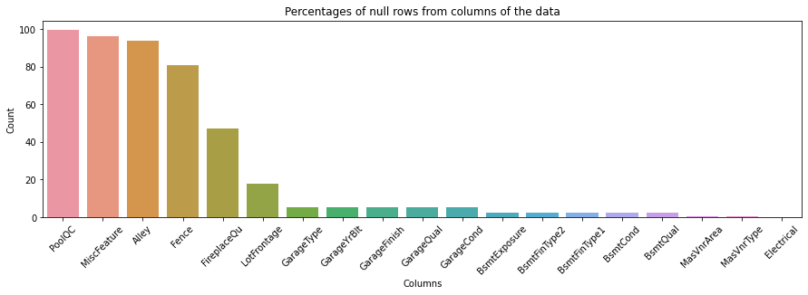

```python
import seaborn as sns
import matplotlib.pyplot as plt
plt.figure(figsize=(15,4))
sns.barplot(x=df_missing.index,y=df_missing.missing_perc)
plt.title('Percentages of null rows from columns of the data')
plt.xlabel('Columns')
plt.ylabel('Count')
plt.xticks(rotation=45)
#plt.plot([0, 18], [10, 10], 'g', lw=2)
plt.show()
```

**From this, it can be seen:**

| About **100%** of houses do not have Pool, Miscellaneous feature and No alley access |
| --- |
| More than **80%** of records do not have Fence |
| About **50%** of records do not have fireplaces |

This means that the empty values not always mean missing values but tell **another story.**

However, there are others variables which we cannot say the same.

So It is important to procced a data cleaning process.

## Data Cleaning

In this section, some attributes will be filled due to its values are important for the later analysis

```python
# numerical
df_train.LotFrontage=df_train.groupby("Neighborhood")["LotFrontage"].transform(lambda x: x.fillna(x.median()))
df_train.MasVnrArea=df_train.MasVnrArea.fillna(0) # Those values in Nan for MasVnrArea are because this house do not have Masonry veneer.
#categorical
df_train['MSZoning'] = df_train.groupby("Neighborhood")["MSZoning"].transform(lambda x: x.fillna(x.mode()))
df_train['Electrical'] = df_train.groupby("Neighborhood")["Electrical"].transform(lambda x: x.fillna(x.mode()[0]))
```

Since the previous code was only sustituted the columns: **LotFrontage**,**MSZoning**, **MasVnrArea** and **Electrical**,the rest of the attributes with null values can be substituted by **None** because this value makes sense in the categories.

```python
missing={}
for i in df_train:
    if df_train[i].isna().sum()>0:
        missing.update({i:df_train[i].isna().sum()})
```

```python
df_missing=pd.DataFrame(missing,index=['Count']).transpose().sort_values(by='Count',ascending=False)
df_missing.columns=['missing']
for x in df_missing.index:
    df_missing.loc[x,'missing_perc']=df_missing.loc[x,'missing']/len(df_train[x])*100
```

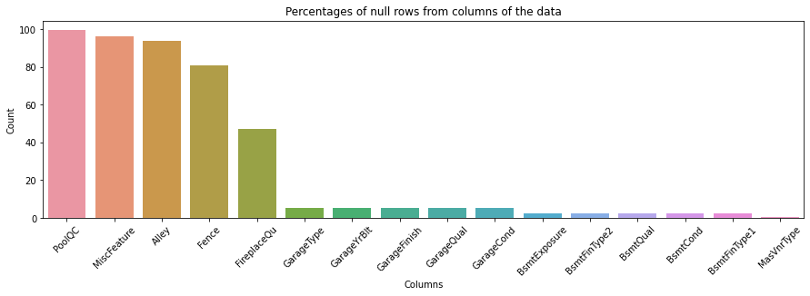

```python
import seaborn as sns
import matplotlib.pyplot as plt
plt.figure(figsize=(15,4))
sns.barplot(x=df_missing.index,y=df_missing.missing_perc)
plt.title('Percentages of null rows from columns of the data')
plt.xlabel('Columns')
plt.ylabel('Count')
plt.xticks(rotation=45)
#plt.plot([0, 18], [10, 10], 'g', lw=2)
plt.show()
```

Now, it left *16 attributes* with **NaN**

```python
attri_null=pd.DataFrame(df_train.isnull().sum()[df_train.isnull().sum()>0]).rename({0:'Count'},axis=1).sort_values(by='Count',ascending=False)
for i in attri_null.index:
    print(i)
    if 'None' not in df_train[i].cat.categories:
        df_train[i]=df_train[i].cat.add_categories(['None'])
    df_train[i] = df_train[i].fillna('None')
```

```
PoolQC
MiscFeature
Alley
Fence
FireplaceQu
GarageType
GarageYrBlt
GarageFinish
GarageQual
GarageCond
BsmtExposure
BsmtFinType2
BsmtQual
BsmtCond
BsmtFinType1
MasVnrType
```

```python
print('There are {} columns with NULL values'.format(len(df_train.isnull().sum()[df_train.isnull().sum()>0])))
```

```
There are 0 columns with NULL values
```

#### Great!. There is not more NULL values in the dataset.

## Univariable analysis

### Numerical variables

```python
def plot_subplot(itera,n,label,compare=''):
    row=int(len(itera)/n)+len(itera)%n
    colu=len(itera)-row*n

    if label=='hist':
        plt.figure(figsize=(16,6*row))
        for i,j in enumerate(itera):
            i+=1
            plt.subplot(row,n,i)
            sns.violinplot(data=df_train,y=j,kde=True,hue='Neighborhood')
            plt.title('Distribution of '+j)
    elif label=='cross':
            a=0
            b=0
            fig, axes=plt.subplots(row,n,figsize=(16,8*row))
            #print(row,n)
            for i,j in enumerate(itera):
                i+=1
                my_crosstab = df_train[j].value_counts(sort=False)/sum(df_train[j].value_counts(sort=False))*100
                if row==1 or n==1:
                    #print('a',a,b)
                    ax=my_crosstab.plot(kind='bar', stacked=True, rot=90,ax=axes[a],title='Count of '+j)
                    #ax.set_xlabel(j)
                    ax.set_ylabel('% Count')
                else:
                    #print(a,b)
                    ax=my_crosstab.plot(kind='bar', stacked=True, rot=90,ax=axes[a,b],title='Count of '+j)
                    ax.set_xlabel(j)
                    ax.set_ylabel('% Count')
                if b==n-1:
                    b=0
                    a+=1
                else:
                    b+=1
```

```python
df_train.describe().round(1)
```

|  | Id | LotFrontage | LotArea | MasVnrArea | BsmtFinSF1 | BsmtFinSF2 | BsmtUnfSF | TotalBsmtSF | 1stFlrSF | 2ndFlrSF | LowQualFinSF | GrLivArea | GarageArea | WoodDeckSF | OpenPorchSF | EnclosedPorch | 3SsnPorch | ScreenPorch | PoolArea | MiscVal | SalePrice |
| --- | --- | --- | --- | --- | --- | --- | --- | --- | --- | --- | --- | --- | --- | --- | --- | --- | --- | --- | --- | --- | --- |
| count | 1460.0 | 1460.0 | 1460.0 | 1460.0 | 1460.0 | 1460.0 | 1460.0 | 1460.0 | 1460.0 | 1460.0 | 1460.0 | 1460.0 | 1460.0 | 1460.0 | 1460.0 | 1460.0 | 1460.0 | 1460.0 | 1460.0 | 1460.0 | 1460.0 |
| mean | 730.5 | 70.2 | 10516.8 | 103.1 | 443.6 | 46.5 | 567.2 | 1057.4 | 1162.6 | 347.0 | 5.8 | 1515.5 | 473.0 | 94.2 | 46.7 | 22.0 | 3.4 | 15.1 | 2.8 | 43.5 | 180921.2 |
| std | 421.6 | 22.4 | 9981.3 | 180.7 | 456.1 | 161.3 | 441.9 | 438.7 | 386.6 | 436.5 | 48.6 | 525.5 | 213.8 | 125.3 | 66.3 | 61.1 | 29.3 | 55.8 | 40.2 | 496.1 | 79442.5 |
| min | 1.0 | 21.0 | 1300.0 | 0.0 | 0.0 | 0.0 | 0.0 | 0.0 | 334.0 | 0.0 | 0.0 | 334.0 | 0.0 | 0.0 | 0.0 | 0.0 | 0.0 | 0.0 | 0.0 | 0.0 | 34900.0 |
| 25% | 365.8 | 60.0 | 7553.5 | 0.0 | 0.0 | 0.0 | 223.0 | 795.8 | 882.0 | 0.0 | 0.0 | 1129.5 | 334.5 | 0.0 | 0.0 | 0.0 | 0.0 | 0.0 | 0.0 | 0.0 | 129975.0 |
| 50% | 730.5 | 70.0 | 9478.5 | 0.0 | 383.5 | 0.0 | 477.5 | 991.5 | 1087.0 | 0.0 | 0.0 | 1464.0 | 480.0 | 0.0 | 25.0 | 0.0 | 0.0 | 0.0 | 0.0 | 0.0 | 163000.0 |
| 75% | 1095.2 | 80.0 | 11601.5 | 164.2 | 712.2 | 0.0 | 808.0 | 1298.2 | 1391.2 | 728.0 | 0.0 | 1776.8 | 576.0 | 168.0 | 68.0 | 0.0 | 0.0 | 0.0 | 0.0 | 0.0 | 214000.0 |
| max | 1460.0 | 313.0 | 215245.0 | 1600.0 | 5644.0 | 1474.0 | 2336.0 | 6110.0 | 4692.0 | 2065.0 | 572.0 | 5642.0 | 1418.0 | 857.0 | 547.0 | 552.0 | 508.0 | 480.0 | 738.0 | 15500.0 | 755000.0 |

```python
integers=list(df_train.describe().round(1).columns.drop('Id'))
```

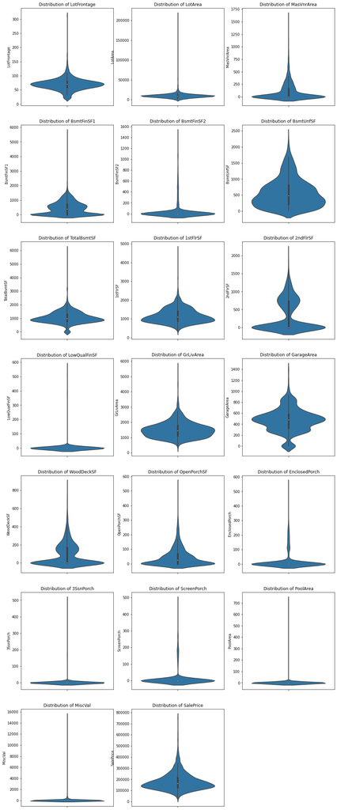

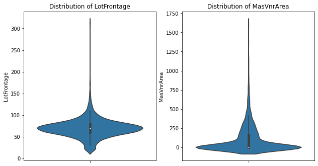

```python
plot_subplot(integers,3,'hist')
plot_subplot(floats,3,'hist')
```

### Categorical variables

[figure not shown]

```python
plot_subplot(categories,2,'cross','GarageQual')
```

## Bivariable analysis

### Numerical variables

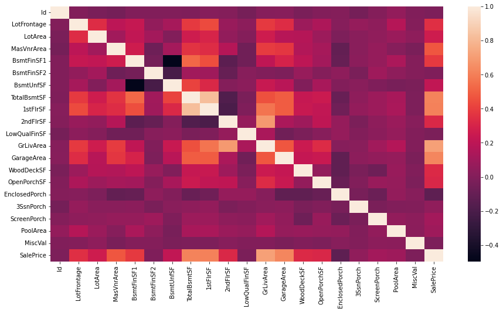

```python
plt.figure(figsize=(15,8))
sns.heatmap(df_train.corr())
```

### Hypothesis 1

This analyzis will be answered within some hypothesis proposted.

**Is the Exterior covering on house associated with lot configuration ?**

**LotConfig:** Lot configuration

| Category | Meaning |
| --- | --- |
| Inside | Inside lot |
| Corner | Corner lot |
| CulDSac | Cul-de-sac |
| FR2 | Frontage on 2 sides of property |
| FR3 | Frontage on 3 sides of property |

**Exterior1st:** Exterior covering on house

| Category | Meaning |
| --- | --- |
| AsbShng | Asbestos Shingles |
| AsphShn | Asphalt Shingles |
| BrkComm | Brick Common |
| BrkFace | Brick Face |
| CBlock | Cinder Block |
| CemntBd | Cement Board |
| HdBoard | Hard Board |
| ImStucc | Imitation Stucco |
| MetalSd | Metal Siding |
| Other | Other |
| Plywood | Plywood |
| PreCast | PreCast |
| Stone | Stone |
| Stucco | Stucco |
| VinylSd | Vinyl Siding |
| Wd Sdng | Wood Siding |
| WdShing | Wood Shingles |

```python
def plot_subplot2(itera,n,label,compare=''):
    row=int(len(itera)/n)+len(itera)%n
    colu=len(itera)-row*n

    if label=='hist':
        plt.figure(figsize=(16,6*row))
        for i,j in enumerate(itera):
            i+=1
            plt.subplot(row,n,i)
            sns.violinplot(data=df_train,y=j,kde=True,hue='Neighborhood')
            plt.title('Distribution of '+j)
    elif label=='cross':
            a=0
            b=0
            fig, axes=plt.subplots(row,n,figsize=(16,6*row))
            #print(row,n)
            for i,j in enumerate(itera):
                i+=1
                my_crosstab = pd.crosstab(index=df_train[j],
                                columns=df_train[compare])
                if row==1:
                    #print('a',a,b)
                    my_crosstab.plot(kind='bar', stacked=True, rot=90,ax=axes[a])

                else:
                    #print(a,b)
                    my_crosstab.plot(kind='bar', stacked=True, rot=90,ax=axes[a,b])
                if b==n-1:
                    b=0
                    a+=1
                else:
                    b+=1
```

```python
def chi_square_mul(itera):
    d={}
    from scipy.stats import chi2_contingency
    for j in itera:
        for i in itera:
            if not i==j:
                my_crosstab = pd.crosstab(index=df_train[i], columns=df_train[j])
                # Chi-square test of independence.
                c, p, dof, expected = chi2_contingency(my_crosstab)
                # Print the p-value
                d.update({(i,j):p})
    return d
```

The hypothesis will be test looks like:

**$H_0$:** *LotConfig* and *Exterior1st* are independent to each other among all subjects in the population

**$H_a$:** *LotConfig* and *Exterior1st* are **NOT** independent to each other among all subjects in the population

#### Visual demostration

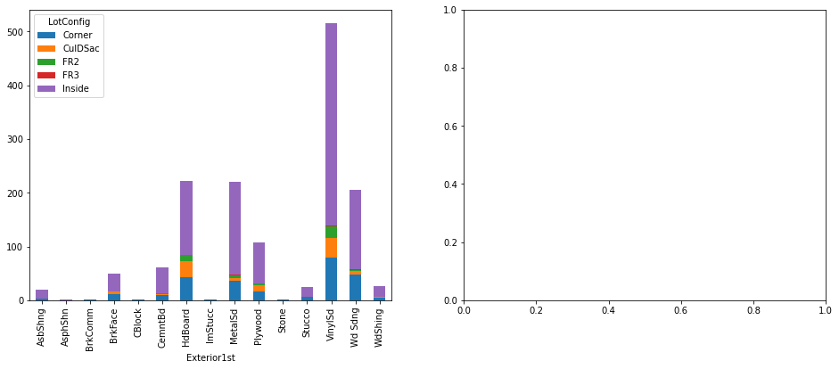

```python
plot_subplot2(['Exterior1st'],2,'cross','LotConfig')
```

#### Statistical demostration

```python
p_value_interest=chi_square_mul(('LotConfig','Exterior1st'))
print('With 95% of confidence, the p-value for LotConfig and Exterior1st is {:.2f}'.format(list(p_value_interest.values())[0]))
```

```
With 95% of confidence, the p-value for LotConfig and Exterior1st is 0.07
```

Taking account this:

- p(X) < 0.01 very strong evidence,
- p(X) ∈ (0.01, 0.05) strong evidence,
- p(X) ∈ (0.05, 0.1) weak evidence,
- p(X) > 0.1 little or no evidence.

This mean as there is a **weak evidence** to rejected the null hypothesis, it can be concluded that **LotConfig** and **Exterior1st** are independent to each other among all population

### Hypothesis 2

**Is the roof style of the house associated with Neighborhood ?**

**RoofStyle:** Type of roof

| Category |
| --- |
| Flat |
| Gable |
| Gambrel |
| Hip |
| Mansard |
| Shed |

**Neighborhood:** Physical locations within Ames city limits

| Category | Details |
| --- | --- |
| Blmngtn | Bloomington Heights |
| Blueste | Bluestem |
| BrDale | Briardale |
| BrkSide | Brookside |
| ClearCr | Clear Creek |
| CollgCr | College Creek |
| Crawfor | Crawford |
| Edwards | Edwards |
| Gilbert | Gilbert |
| IDOTRR | Iowa DOT and Rail Road |
| MeadowV | Meadow Village |
| Mitchel | Mitchell |
| Names | North Ames |
| NoRidge | Northridge |
| NPkVill | Northpark Villa |
| NridgHt | Northridge Heights |
| NWAmes | Northwest Ames |
| OldTown | Old Town |
| SWISU | South & West of Iowa State University |
| Sawyer | Sawyer |
| SawyerW | Sawyer West |
| Somerst | Somerset |
| StoneBr | Stone Brook |
| Timber | Timberland |
| Veenker | Veenker |

The hypothesis will be test looks like:

**$H_0$:** *RoofStyle* and *Neighborhood* are independent to each other among all subjects in the population

**$H_a$:** *RoofStyle* and *Neighborhood* are **NOT** independent to each other among all subjects in the population

#### Visual demostration

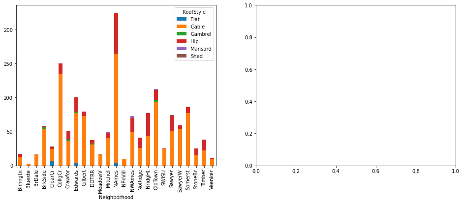

```python
plot_subplot2(['Neighborhood'],2,'cross','RoofStyle')
```

#### Statistical demostration

```python
p_value_interest=chi_square_mul(('Neighborhood','RoofStyle'))
print('With 95% of confidence, the p-value for Neighborhood and RoofStyle is {:.2f}'.format(list(p_value_interest.values())[0]))
```

```
With 95% of confidence, the p-value for Neighborhood and RoofStyle is 0.00
```

Taking account this:

- p(X) < 0.01 very strong evidence,
- p(X) ∈ (0.01, 0.05) strong evidence,
- p(X) ∈ (0.05, 0.1) weak evidence,
- p(X) > 0.1 little or no evidence.

### Hypothesis 3

**Is the type of dwelling involved in the sale associated with the general zoning classification of the sale. ?**

**MSSubClass:** Identifies the type of dwelling involved in the sale.

| Category | Details |
| --- | --- |
| 20 | 1-STORY 1946 & NEWER ALL STYLES |
| 30 | 1-STORY 1945 & OLDER |
| 40 | 1-STORY W/FINISHED ATTIC ALL AGES |
| 45 | 1-1/2 STORY - UNFINISHED ALL AGES |
| 50 | 1-1/2 STORY FINISHED ALL AGES |
| 60 | 2-STORY 1946 & NEWER |
| 70 | 2-STORY 1945 & OLDER |
| 75 | 2-1/2 STORY ALL AGES |
| 80 | SPLIT OR MULTI-LEVEL |
| 85 | SPLIT FOYER |
| 90 | DUPLEX - ALL STYLES AND AGES |
| 120 | 1-STORY PUD (Planned Unit Development) - 1946 & NEWER |
| 150 | 1-1/2 STORY PUD - ALL AGES |
| 160 | 2-STORY PUD - 1946 & NEWER |
| 180 | PUD - MULTILEVEL - INCL SPLIT LEV/FOYER |
| 190 | 2 FAMILY CONVERSION - ALL STYLES AND AGES |

**MSZoning:** Identifies the general zoning classification of the sale.

| Category | Meaning |
| --- | --- |
| A | Agriculture |
| C | Commercial |
| FV | Floating Village Residential |
| I | Industrial |
| RH | Residential High Density |
| RL | Residential Low Density |
| RP | Residential Low Density Park |
| RM | Residential Medium Density |

The hypothesis will be test looks like:

**$H_0$:** *MSSubClass* and *MSZoning* are independent to each other among all subjects in the population

**$H_a$:** *MSSubClass* and *MSZoning* are **NOT** independent to each other among all subjects in the population

#### Visual demostration

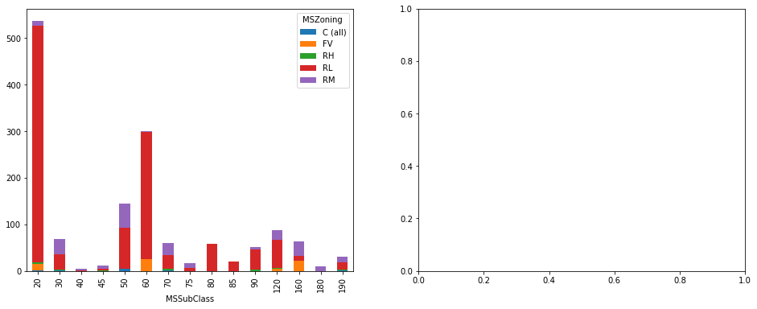

```python
plot_subplot2(['MSSubClass'],2,'cross','MSZoning')
```

#### Statistical demostration

```python
p_value_interest=chi_square_mul(('MSSubClass','MSZoning'))
print('With 95% of confidence, the p-value for Neighborhood and RoofStyle is {:.2f}'.format(list(p_value_interest.values())[0]))
```

[output not shown]

Taking account this:

- p(X) < 0.01 very strong evidence,
- p(X) ∈ (0.01, 0.05) strong evidence,
- p(X) ∈ (0.05, 0.1) weak evidence,
- p(X) > 0.1 little or no evidence.